# Data Handling: Import, Cleaning and Visualisation

Lecture 9:  
Exploratory Data Analysis and Visualization, Part I

Dr. Aurélien Sallin

2026-11-26

# Recap and warmup

## Data preparation and cleaning

##### Know how to prepare a dataset for analysis

- Structure data: tidy data
- Manipulate data frames with `dplyr`
- Reshape data frames
- Combine data frames
- Clean data: find duplicates, handle missing values, make values consistent

[figure not shown]

## Clean and manipulate data

Source: [Intro to R for Social Scientists](https://jaspertjaden.github.io/course-intro2r/week3.html)

## Clean and manipulate data: your turn 🫵

Consider the following data frame:

```
main_dataset
  city        temp  scale conversion_factor
1 StGallen    12 Celsius 1.0000000
2 Zürich      14 Celsius 1.0000000
3 Detroit     40 Fahrenheit 0.5555556
```

Select all the statements that are true.

```r
main_dataset |>
  mutate(temp_celsius = if_else(
    scale == "Fahrenheit", (temp-32) * conversion_factor, temp)
  )
```

replaces the variable `temp` with `temp_celsius`

```r
main_dataset |>
  mutate(temp_celsius = if_else(
    scale == "Fahrenheit", (temp-32) * conversion_factor, temp)
  )
```

has 3 rows and 5 columns

```r
main_dataset |>
  summarize(mean_temp = mean(temp), min_temp = min(temp))
```

returns a tibble containing 2 columns and 1 row

```r
main_dataset |>
  summarize(mean_scale = mean(scale), sd_scale = sd(scale))
```

is a good way to get summary statistics for the variable `scale`

## OK Boomer

[figure not shown]

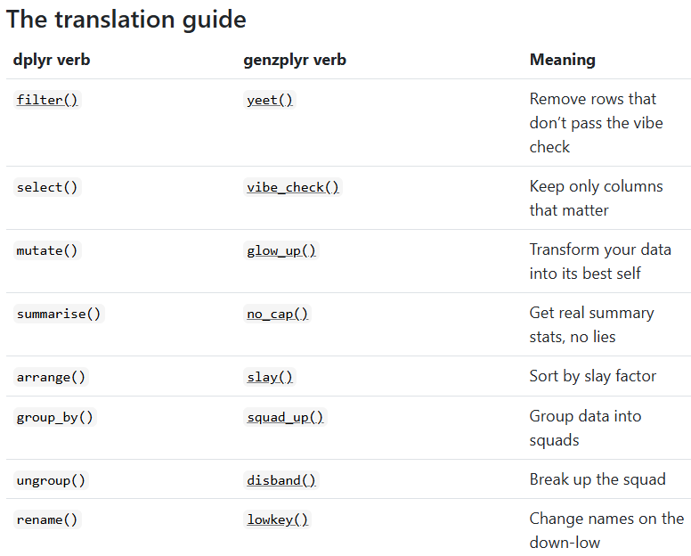

`anti_join()` -> `ghost()` (i.e. “*forget about those who don’t vibe with you*”). See [Hadley Wickham’s Genzplyr](https://hadley.github.io/genzplyr/)

## Reshape and stack datasets

#### From wide to long and vice-versa

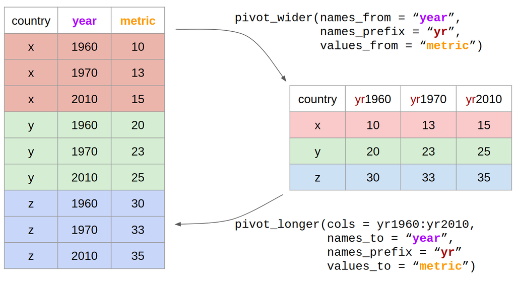

Long and wide data. Source: [Hugo Tavares](https://tavareshugo.github.io/r-intro-tidyverse-gapminder/09-reshaping/index.html)

#### Bind or stack rows using `bind_rows()`

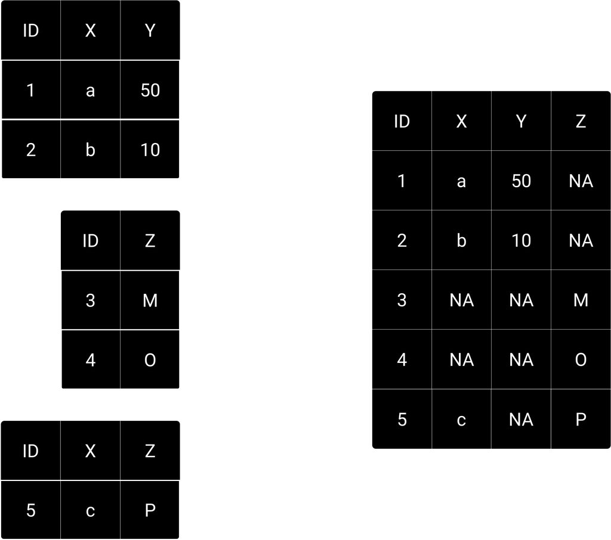

## Joining dataset

| dplyr (tidyverse) | base::merge |
| --- | --- |
| `inner_join(x, y)` | `merge(x, y)` |
| `left_join(x, y)` | `merge(x, y, all.x = TRUE)` |
| `right_join(x, y)` | `merge(x, y, all.y = TRUE)`, |
| `full_join(x, y)` | `merge(x, y, all = TRUE)` |

Source: [R4DS](https://r4ds.hadley.nz/joins). You are expected to know that `base::merge()` exists. For the exam, please focus on the `dplyr` functions.

## Joining dataset: your turn 🫵🧠

Consider the following code:

```r
temperature_conversions <- data.frame(conversion_factor = c(5/9, 1),
                                      scale = c("Fahrenheit", "Celsius"))

temperature <- data.frame(city = c("StGallen", "Zürich", "Detroit"),
                          temp = c(12, 14, 21),
                          scale = c("Cel", "Cel", "F"))
```

Select statements that are true:

- `inner_join(temperature, temperature_conversions, by="scale")` returns a data frame with 3 rows.
- `left_join(temperature, temperature_conversions, by="scale")` returns a data frame with 3 rows.
- `full_join(temperature, temperature_conversions, by="scale")` returns a data frame with 3 rows.

## Missing Values

1. Keep in mind the **source of missingness throughout your analysis**:

   - Value is known but recorded badly  
   - Value is unknown and completely missing at random (MCAR)  
   - Value is unknown and missing at random (MAR)  
   - Value is unknown and not missing at random (MNAR)
2. Be aware of the **trade-off between data loss and bias**
3. **Choose imputation methods wisely** (or, maybe, don’t bother)

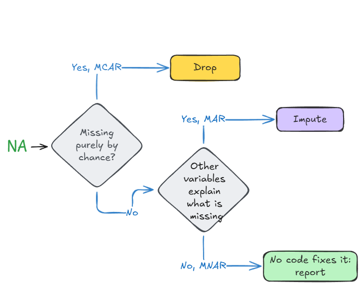

## More on missing values

##### As I prepared the course, I realized Lecture 8 was lacking examples.

[figure not shown]

- Please check the Appendix on Missing values.
- It walks you through the algorithm with some examples of my own (and of [Van Buuren, 2018](https://stefvanbuuren.name/fimd/))
- This would make the concepts developed in Lecture 8 concrete.
- Exam relevant 😉

# Exploratory Data Analysis and Descriptive Statistics

## Goals for the next two lectures

1. Know how to conduct exploratory data analysis (EDA) using a real-life example.
2. Visualize data using tables.
3. Visualize data using the grammar of graphics.
4. Produce effective data visualization.

“To not mislead others and not embarrass yourself, know your data”.*  
*“Statistics for Public Policy” by Jeremy G. Weber, 2024.

## Exploratory Data Analysis (EDA) is the first step of data analysis

- 🔎 Get a first understanding of your dataset.
- Show **key aspects of data** by modelling, transforming, and visualizing your data.
  - Investigate the quality and reliability of your data.
  - Inform your own statistical analysis.
  - Inform audience (helps understand analytics parts).
- … which in turns generates new questions about your dataset (creative process 🎨).

## Three questions to ask your dataset

##### 1. What is the underlying structure of your dataset?

- **Unit of observation** and number of observations
- **What variables measure**: USD or PPP? “Intelligence” or IQ?
- **Quality**: how were the data collected? Which values are missing, and why?

##### 2. What type of variation occurs within my variables?

- **Typical values**: mean, mode, range, standard deviation, missing values.
- **Surprising values**: outliers, anomalies, unusual patterns.

##### 3. What type of covariation occurs between my variables?

- **Covariation** and **Patterns**.

Sources: [R4DS Chapter 10](https://r4ds.hadley.nz/eda).

## EDA: first steps in `R`

- Quick overview: `summary()`, `str()`, `glimpse()` (`dplyr`)
- Cross-tabulation: `table()`
- Summarizing tools: `skimr`, `summarytools`, `janitor` (also cleaning)

## EDA: first steps in `R`

#### 1. Functions to compute statistics

- e.g., `mean()`, `min()`, `max()`

#### 2. Functions to *apply* the statistics function to one or several columns in a tidy dataset.

- Including all values in a column.
- By group (observation categories, e.g. by location, year, etc.)

`summary()` in `base`; `summarize()` in `tidyverse`; `group_by()` in `tidyverse`; `sapply()`, `apply()`, `lapply()`, etc. in `base`; `skimr` package; etc.

# Let’s get real

## Exploring Swiss healthcare costs

#### We will explore the **Monitoring of ongoing cost development** dataset

- Current trends in gross benefits per person by canton of residence and cost group.
- 4 updates per year.
- Time series by cost group, age group and canton from 1997.
- Data extracted on 21.11.2026, available on the [FOPH Website](https://www.bag.admin.ch/de/monitoring-der-krankenversicherungs-kostenentwicklung-mokke)

[figure not shown]

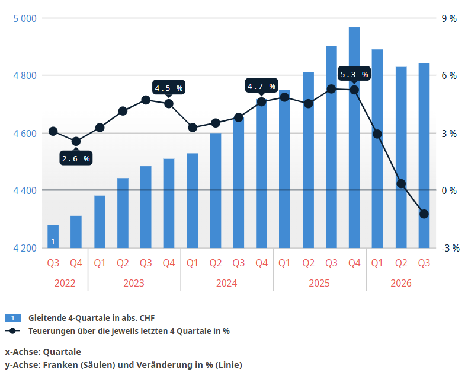

## Load and check

#### Load and check first rows

```r
library(readxl)
costs <- read_excel("../../data/health_costs_canton.xlsx")
```

```r
head(costs)
## # A tibble: 6 × 5
##   canton sex    year cost_pc region
##   <chr>  <chr> <dbl>   <dbl> <chr>
## 1 CH     total  1997   1885. <NA>
## 2 CH     total  1998   1937. <NA>
## 3 CH     total  1999   2059. <NA>
## 4 CH     total  2000   2197. <NA>
## 5 CH     total  2001   2295. <NA>
## 6 CH     total  2002   2364. <NA>
```

#### Use `glimpse()` and `dim()`

```r
glimpse(costs)
## Rows: 2,268
## Columns: 5
## $ canton  <chr> "CH", "CH", "CH", "CH", "CH", "CH", "CH", "CH", "CH", "CH", "CH", "CH", "CH", "CH"…
## $ sex     <chr> "total", "total", "total", "total", "total", "total", "total", "total", "total", "…
## $ year    <dbl> 1997, 1998, 1999, 2000, 2001, 2002, 2003, 2004, 2005, 2006, 2007, 2008, 2009, 2010…
## $ cost_pc <dbl> 1885.30, 1936.58, 2058.75, 2197.32, 2295.30, 2363.63, 2475.06, 2657.37, 2716.11, 2…
## $ region  <chr> NA, NA, NA, NA, NA, NA, NA, NA, NA, NA, NA, NA, NA, NA, NA, NA, NA, NA, NA, NA, NA…
```

```r
dim(costs)
## [1] 2268    5
```

2268 rows, 5 columns

## Call `summary()`

```r
summary(costs)
##        canton            sex            year         cost_pc             region
##  Length   :2268   Length   :2268   Min.   :1997   Min.   : 977.9   Length   :2268
##  N.unique :  27   N.unique :   3   1st Qu.:2004   1st Qu.:2306.6   N.unique :   3
##  N.blank  :   0   N.blank  :   0   Median :2010   Median :3006.9   N.blank  :   0
##  Min.nchar:   2   Min.nchar:   3   Mean   :2010   Mean   :3060.4   Min.nchar:   6
##  Max.nchar:   2   Max.nchar:   5   3rd Qu.:2017   3rd Qu.:3710.5   Max.nchar:   7
##                                    Max.   :2024   Max.   :6488.0   NAs      :  84
```

#### Check first difference between characters and numeric variables

- 5 variables, 3 characters, 2 numeric
- **Characters**: 27 unique cantons, 3 unique sexes, 3 unique regions with 84 `NA`s
- **Numeric**: year from 1997 to 2024, costs from 977.9 to 6488.0

## Use `skimr`: “a frictionless approach to summary statistics”

```r
library(skimr)
skim(costs)
```

**Variable type: character**

| skim_variable | n_missing | complete_rate | min | max | empty | n_unique | whitespace |
| --- | --- | --- | --- | --- | --- | --- | --- |
| canton | 0 | 1.00 | 2 | 2 | 0 | 27 | 0 |
| sex | 0 | 1.00 | 3 | 5 | 0 | 3 | 0 |
| region | 84 | 0.96 | 6 | 7 | 0 | 3 | 0 |

**Variable type: numeric**

| skim_variable | n_missing | complete_rate | mean | sd | p0 | p25 | p50 | p75 | p100 |
| --- | --- | --- | --- | --- | --- | --- | --- | --- | --- |
| year | 0 | 1 | 2010.50 | 8.08 | 1997.00 | 2003.75 | 2010.50 | 2017.25 | 2024.00 |
| cost_pc | 0 | 1 | 3060.36 | 984.63 | 977.93 | 2306.62 | 3006.92 | 3710.54 | 6487.97 |

Here printed without `skimr`’s summary subtable and without charts. Check the [`skimr` Package Vignette](https://docs.ropensci.org/skimr/) for more customization.

## Use `summarytools`

```r
library(summarytools)
dfSummary(costs)
```

| **Variable** | **Stats / Values** | **Freqs (% of Valid)** | **Graph** | **Missing** |
| --- | --- | --- | --- | --- |
| canton [character] | 1. AG 2. AI 3. AR [ 24 others ] | 84 ( 3.7% ) 84 ( 3.7% ) 84 ( 3.7% ) 2016 ( 88.9% ) |  | 0 (0.0%) |
| sex [character] | 1. men 2. total 3. women | 756 ( 33.3% ) 756 ( 33.3% ) 756 ( 33.3% ) |  | 0 (0.0%) |
| year [numeric] | Mean (sd) : 2010.5 (8.1) min ≤ med ≤ max: 1997 ≤ 2010.5 ≤ 2024 IQR (CV) : 13.5 (0) | 28 distinct values |  | 0 (0.0%) |
| cost_pc [numeric] | Mean (sd) : 3060.4 (984.6) min ≤ med ≤ max: 977.9 ≤ 3006.9 ≤ 6488 IQR (CV) : 1403.9 (0.3) | 2266 distinct values |  | 0 (0.0%) |
| region [character] | 1. French 2. German 3. Italian | 504 ( 23.1% ) 1596 ( 73.1% ) 84 ( 3.8% ) |  | 84 (3.7%) |

Generated by summarytools 1.1.5 ([R](https://www.r-project.org/) version 4.6.1)  
2026-11-25

## What is the unit of observation?

- Unit of observation: **canton x year** or **canton x gender x year**  
  (one measurement per canton per year, for the population and per gender).
- This is a **panel data**.

**One observation per canton, year, sex**

```r
costs |>
    count(canton, year, sex) |>
    head(6)
## # A tibble: 6 × 4
##   canton  year sex       n
##   <chr>  <dbl> <chr> <int>
## 1 AG      1997 men       1
## 2 AG      1997 total     1
## 3 AG      1997 women     1
## 4 AG      1998 men       1
## 5 AG      1998 total     1
## 6 AG      1998 women     1
```

**No duplicates at the unit of observation level**

```r
costs |>
    summarize(n = n(), .by = c(canton, year, sex)) |>
    filter(n > 1)
## # A tibble: 0 × 4
## # ℹ 4 variables: canton <chr>, year <dbl>, sex <chr>, n <int>
```

## What is the unit of observation?

```r
costs  |>
  group_by(region, canton, sex)  |>
  summarize(
    n_distinct(year),
    min(year),
    max(year)
  )
## # A tibble: 81 × 6
## # Groups:   region, canton [27]
##    region canton sex   `n_distinct(year)` `min(year)` `max(year)`
##    <chr>  <chr>  <chr>              <int>       <dbl>       <dbl>
##  1 French FR     men                   28        1997        2024
##  2 French FR     total                 28        1997        2024
##  3 French FR     women                 28        1997        2024
##  4 French GE     men                   28        1997        2024
##  5 French GE     total                 28        1997        2024
##  6 French GE     women                 28        1997        2024
##  7 French JU     men                   28        1997        2024
##  8 French JU     total                 28        1997        2024
##  9 French JU     women                 28        1997        2024
## 10 French NE     men                   28        1997        2024
## # ℹ 71 more rows
```

#### We check **whether the panel is complete**: min, max, number of distinct years per region x canton x sex

- 81 units: 1 for the country, 2 for the country x sex, 26 x 1 for population, 52 for canton x sex.

## What to do with missing values? What is the source of missingness?

#### We saw that there were 84 `NA`s in the region variable.

```r
costs |>
    count(region)
## # A tibble: 4 × 2
##   region      n
##   <chr>   <int>
## 1 French    504
## 2 German   1596
## 3 Italian    84
## 4 <NA>       84

costs |>
    count(region, canton) |>
    filter(is.na(region))
## # A tibble: 1 × 3
##   region canton     n
##   <chr>  <chr>  <int>
## 1 <NA>   CH        84

costs <- costs |>
    mutate(region = coalesce(region, "CH"))
```

- It is clear that the `NA` in the region is for the region `CH`.
- Case of **value known but recorded badly**. Replace with “CH”.

## What do variables measure?

- All variables are straightforward, but the variable costs needs clarification.
- The data description says: **gross benefits**. We need to look up what that is (OBSAN):

> “Gross costs of the compulsory health insurance in Switzerland are the total costs billed by healthcare providers for covered services before deducting patient cost-sharing (franchise, deductible/co-payment, and hospital stay contributions)”
- No mention whether it is nominal or real prices. Currency is CHF.

## What do variables measure?

#### Ranges and distributions

```r
costs |>
  filter(canton != "CH", sex == "total") |>
  summarise(
    n         = n(),
    n_missing = sum(is.na(cost_pc)),
    mean      = mean(cost_pc),
    median    = median(cost_pc),
    min       = min(cost_pc),
    max       = max(cost_pc),
    .by = canton
  )  |>
  head(5)
## # A tibble: 5 × 7
##   canton     n n_missing  mean median   min   max
##   <chr>  <int>     <int> <dbl>  <dbl> <dbl> <dbl>
## 1 ZH        28         0 3174.  3137. 1891. 4580.
## 2 BE        28         0 3308.  3402. 1830. 4780.
## 3 LU        28         0 2709.  2693. 1406. 4040.
## 4 UR        28         0 2543.  2549. 1426. 3676.
## 5 SZ        28         0 2734.  2683. 1450. 4071.
```

```r
costs |>
    filter(canton != "CH", sex == "total") |>
    summarise(
        n = n(),
        n_missing = sum(is.na(cost_pc)),
        mean = mean(cost_pc),
        median = median(cost_pc),
        min = min(cost_pc),
        max = max(cost_pc),
        .by = year
    ) |>
    head(5)
## # A tibble: 5 × 7
##    year     n n_missing  mean median   min   max
##   <dbl> <int>     <int> <dbl>  <dbl> <dbl> <dbl>
## 1  1997    26         0 1764.  1678. 1129. 2905.
## 2  1998    26         0 1814.  1710. 1189. 2842.
## 3  1999    26         0 1938.  1821. 1336. 2976.
## 4  2000    26         0 2078.  1945. 1498. 3164.
## 5  2001    26         0 2167.  2045. 1566. 3338.
```

## What type of variation occurs within my variables?

#### Typical values (here for a typical canton)

```r
cantons_total <- costs |>
    filter(canton != "CH", sex == "total")

cantons_total |>
  filter(year %in% c(1997, 2024)) |>
  group_by(year) |>
  summarise(
    mean = mean(cost_pc),
    median = median(cost_pc),
    min = min(cost_pc),
    max = max(cost_pc),
    sd = sd(cost_pc)
  )
## # A tibble: 2 × 6
##    year  mean median   min   max    sd
##   <dbl> <dbl>  <dbl> <dbl> <dbl> <dbl>
## 1  1997 1764.  1678. 1129. 2905.  440.
## 2  2024 4506.  4385. 3405. 5854.  665.
```

A typical canton costs about 4,400 CHF per insured person in 2024, 2.6 times more than in 1997.

## What type of variation occurs within my variables?

#### Which cantons are unusual in their costs?

```r
cantons_total |>
  filter(year == 2024) |>
  slice_max(cost_pc, n = 3)
## # A tibble: 3 × 5
##   canton sex    year cost_pc region
##   <chr>  <chr> <dbl>   <dbl> <chr>
## 1 TI     total  2024   5854. Italian
## 2 GE     total  2024   5721. French
## 3 BS     total  2024   5618. German

cantons_total |>
  filter(year == 2024) |>
  slice_min(cost_pc, n = 3)
## # A tibble: 3 × 5
##   canton sex    year cost_pc region
##   <chr>  <chr> <dbl>   <dbl> <chr>
## 1 AI     total  2024   3405. German
## 2 UR     total  2024   3676. German
## 3 OW     total  2024   3731. German
```

An outlier is not an error! Ticino and Geneva are really expensive… just google it to confirm.

## What type of variation occurs within my variables?

#### We have a panel data, so it’s good to look at the trends over time.

- Use `lag()` in an arranged (❗) and grouped data frame to get typical growth rates.

```r
growth <- cantons_total |>
    arrange(canton, year) |>
    group_by(canton) |>
    mutate(
      lag = lag(cost_pc),
      growth = cost_pc / lag - 1) |>
    ungroup()

growth
## # A tibble: 728 × 7
##    canton sex    year cost_pc region   lag  growth
##    <chr>  <chr> <dbl>   <dbl> <chr>  <dbl>   <dbl>
##  1 AG     total  1997   1507. German   NA  NA
##  2 AG     total  1998   1623. German 1507.  0.0772
##  3 AG     total  1999   1782. German 1623.  0.0978
##  4 AG     total  2000   1898. German 1782.  0.0647
##  5 AG     total  2001   1975. German 1898.  0.0410
##  6 AG     total  2002   2051. German 1975.  0.0381
##  7 AG     total  2003   2186. German 2051.  0.0657
##  8 AG     total  2004   2337. German 2186.  0.0691
##  9 AG     total  2005   2409. German 2337.  0.0310
## 10 AG     total  2006   2483. German 2409.  0.0308
## # ℹ 718 more rows
```

```r
growth |>
    summarise(
        mean = mean(growth, na.rm = TRUE),
        median = median(growth, na.rm = TRUE),
        min = min(growth, na.rm = TRUE),
        max = max(growth, na.rm = TRUE)
    )
## # A tibble: 1 × 4
##     mean median    min   max
##    <dbl>  <dbl>  <dbl> <dbl>
## 1 0.0364 0.0341 -0.119 0.154
```

Costs grow by about 3.5% per year in a typical canton.

## What type of variation occurs within my variables?

```r
growth |>
    filter(abs(growth) > 0.10) |>
    arrange(desc(abs(growth))) |>
    head(10)
## # A tibble: 10 × 7
##    canton sex    year cost_pc region   lag growth
##    <chr>  <chr> <dbl>   <dbl> <chr>  <dbl>  <dbl>
##  1 BE     total  2004   2880. German 2496.  0.154
##  2 NW     total  2012   2809. German 2457.  0.144
##  3 AR     total  2000   1735. German 1542.  0.125
##  4 AI     total  1999   1336. German 1189.  0.123
##  5 AI     total  2000   1498. German 1336.  0.121
##  6 ZG     total  2007   2413. German 2154.  0.120
##  7 AR     total  2012   2880. German 2572.  0.120
##  8 FR     total  1998   1834. French 2082. -0.119
##  9 GL     total  2000   1921. German 1721.  0.116
## 10 BS     total  1999   2925. German 2625.  0.114
```

```r
growth |>
    filter(growth < 0) |>
    count(year) |>
    arrange(-n)
## # A tibble: 13 × 2
##     year     n
##    <dbl> <int>
##  1  2020    14
##  2  2006     6
##  3  2010     6
##  4  1998     3
##  5  2003     2
##  6  2011     2
##  7  2012     2
##  8  2015     2
##  9  2017     2
## 10  2018     2
## 11  2019     2
## 12  2005     1
## 13  2009     1
```

*Strange*: Fribourg 1998 (−12%) and growth rates > 10% are suspicious; 2020 is COVID.

## What type of variation occurs within my variables?

#### Check variation per gender

```r
costs |>
  filter(year %in% c(1997, 2024), canton == "CH") |>
  summarise(
    mean_cost  = mean(cost_pc),
    n_cantons  = n(),
    .by = c(year, sex)
  ) |>
  arrange(sex, year)
## # A tibble: 6 × 4
##    year sex   mean_cost n_cantons
##   <dbl> <chr>     <dbl>     <int>
## 1  1997 men       1546.         1
## 2  2024 men       4185.         1
## 3  1997 total     1885.         1
## 4  2024 total     4694.         1
## 5  1997 women     2208.         1
## 6  2024 women     5198.         1
```

Women are 1013 CHF more expensive than men in 2024, 662 in 1997. Is this plausible?

😮‍💨

# Visualizing data

> “The first thing to do with data is to look at them.” (Crowder & Hand 1990)

## Data visualization is THE key to effectively delivering insights and to convince people

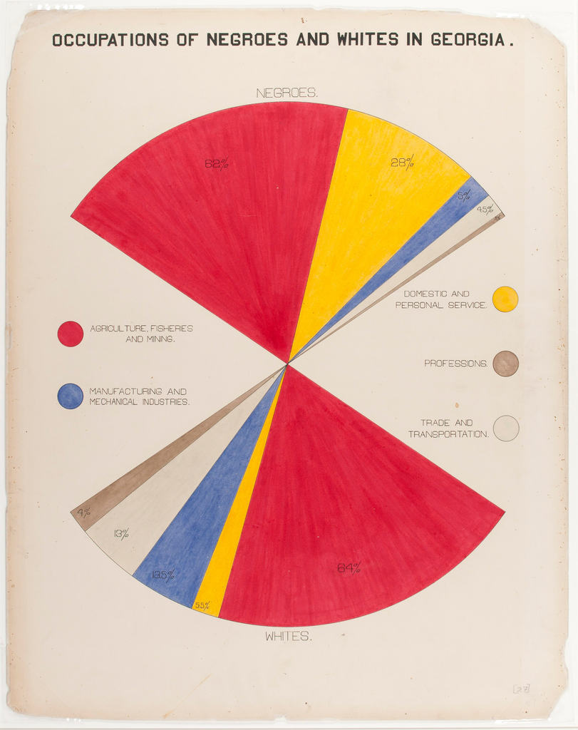

Du Bois, 1900

[figure not shown]

Trump, 2024

## Data visualization through tables and graphs

- Two ways: display data through *tables* or *graphs*.
- Depends on the purpose.

## Data visualization through tables and graphs

###### A **chart** typically contains at least one axis, the **values are represented in terms of visual objects** (dots, lines, bars) and axes typically have scales or labels.

- If we are interested in exploring, analyzing or communicating **patterns** in the data, charts are more useful than tables.

##### A **table** typically contains rows and columns, and the **values are represented by text**.

- If we are interested in exploring, analyzing or communicating **specific numbers** in the data, tables are more useful than graphs.

# Tables

## Tables

- Formatting data values for publication.
- Typical: String operations to make numbers and text look nicer.

##### My advice: the table is self-referencing and requires the *least effort* from the reader

## Tables

The structure and content of a table depend on the analysis. Here: table on costs per sex.

```r
tab <- costs |>
  filter(canton == "CH", year %in% c(1997, 2024)) |>
  select(sex, year, cost_pc) |>
  pivot_wider(
      names_from = year,
      values_from = cost_pc,
      names_prefix = "cost_"
  ) |>
  mutate(growth = cost_2024 / cost_1997 - 1) |>
  arrange(desc(cost_2024))
```

```
# A tibble: 3 × 4
  sex   cost_1997 cost_2024   growth
  <chr>     <dbl>     <dbl>    <dbl>
1 women   2208.11   5197.82 1.353968
2 total   1885.3    4693.63 1.489593
3 men     1546.26   4185.11 1.706602
```

*Problems?*

## Tables: make units clear at first sight

- Decimal marks, units (e.g., currencies), other special characters for special formats (e.g. coordinates).
- Coerce to text using `format()` or the `scales()` package

```r
tab_improved <- tab |>
    mutate(
        across(
          c(cost_1997, cost_2024),
          function(x) {
            scales::number(x, accuracy = 1, big.mark = "'")
          }),
        growth = scales::percent(growth, accuracy = 0.1)
    )
tab_improved
```

```
# A tibble: 3 × 4
  sex   cost_1997 cost_2024 growth
  <chr> <chr>     <chr>     <chr>
1 women 2'208     5'198     135.4%
2 total 1'885     4'694     149.0%
3 men   1'546     4'185     170.7%
```

## Tables: column and row labels must be self-explanatory

```r
tab_improved <- tab_improved |>
    mutate(
        sex = stringr::str_to_title(sex)
    ) |>
    mutate(
        sex = factor(sex, levels = c("Women", "Men", "Total"))
    ) |>
    arrange(sex) |>
    rename(
        "Sex" = sex,
        "Costs in 1997" = cost_1997,
        "Costs in 2024" = cost_2024,
        "Growth rate" = growth
    )
tab_improved
```

```
# A tibble: 3 × 4
  Sex   `Costs in 1997` `Costs in 2024` `Growth rate`
  <fct> <chr>           <chr>           <chr>
1 Women 2'208           5'198           135.4%
2 Men   1'546           4'185           170.7%
3 Total 1'885           4'694           149.0%
```

## Get creative with tables: `gt`

```r
library(gt)
library(gtExtras)

tab |>
  gt() |>
  fmt_number(c(cost_1997, cost_2024), decimals = 0, sep_mark = "'") |>
  fmt_percent(growth, decimals = 0) |>
  cols_label(sex = "Sex", cost_1997 = "Costs in 1997", cost_2024 = "Costs in 2024",
             growth = "Growth rate") |>
  tab_header(title = "Health insurance costs per insured person, Switzerland",
             subtitle = "Women cost more, but men's costs grew faster") |>
  tab_source_note("Source: BAG, MOKKE (gross benefits, OKP).")
```

Health insurance costs per insured person, Switzerland

Women cost more, but men's costs grew faster

| Sex | Costs in 1997 | Costs in 2024 | Growth rate |
| --- | --- | --- | --- |
| women | 2'208 | 5'198 | 135% |
| total | 1'885 | 4'694 | 149% |
| men | 1'546 | 4'185 | 171% |

Source: BAG, MOKKE (gross benefits, OKP).

## Pump up your `gt` with some `gtExtras` sparklines 🔎

```r
# the yearly costs 1997-2024 per sex, stored in one cell (for the sparkline)
trend <- costs |>
  filter(canton == "CH") |>
  arrange(year) |>
  summarise(trend = list(cost_pc), .by = sex)

# same base table as before, plus the trend
tab <- costs |>
  filter(canton == "CH", year %in% c(1997, 2024)) |>
  select(sex, year, cost_pc) |>
  pivot_wider(
      names_from = year,
      values_from = cost_pc,
      names_prefix = "cost_"
  ) |>
  mutate(growth = cost_2024 / cost_1997 - 1) |>
  left_join(trend, join_by(sex)) |>
  mutate(sex = factor(str_to_title(sex), levels = c("Women", "Men", "Total"))) |>
  arrange(sex)

tab_spark <- tab |>
  gt() |>
  fmt_number(c(cost_1997, cost_2024), decimals = 0, sep_mark = "'") |>
  fmt_percent(growth, decimals = 0) |>
  gt_plt_sparkline(trend) |>
  cols_label(sex = "Sex", cost_1997 = "Costs in 1997", cost_2024 = "Costs in 2024",
             growth = "Growth rate", trend = "1997-2024") |>
  tab_header(title = "Health insurance costs per insured person, Switzerland",
             subtitle = "Women cost more, but men's costs grew faster") |>
  tab_source_note("Source: BAG, MOKKE (gross benefits, OKP).")
```

Health insurance costs per insured person, Switzerland

Women cost more, but men's costs grew faster

| Sex | Costs in 1997 | Costs in 2024 | Growth rate | 1997-2024 |
| --- | --- | --- | --- | --- |
| Women | 2'208 | 5'198 | 135% |  |
| Men | 1'546 | 4'185 | 171% |  |
| Total | 1'885 | 4'694 | 149% |  |

Source: BAG, MOKKE (gross benefits, OKP).

## The other tool to know: `modelsummary` 🔎

- Many tools for tables in R: `gt` or `kable()`, etc.
- For economists, `modelsummary` works well for **descriptive statistics** and **regression tables**.
- Many outputs possible: HTML, LaTeX, Word, PDF.

#### Descriptive statistics in one line

```r
library(modelsummary)
datasummary(sex ~ cost_pc * (Mean + SD + Min + Max),
            data = filter(costs, canton == "CH"),
            fmt = 0)
```

[output not shown]

#### Your own summary table, per group

```r
library(modelsummary)
datasummary(sex ~ cost_pc * (Mean + SD + Min + Max),
            data = filter(costs, canton == "CH"),
            fmt = 0)
```

| sex | Mean | SD | Min | Max |
| --- | --- | --- | --- | --- |
| men | 2772 | 769 | 1546 | 4185 |
| total | 3213 | 813 | 1885 | 4694 |
| women | 3642 | 862 | 2208 | 5198 |

# Graphs with R (ggplot2)

## Graphs with R

#### Three main approaches:

1. The original `graphics` package shipped with the base R installation.
2. The `lattice` package, an implementation of the original Bell Labs ‘Trellis’ system.
3. The *`ggplot2`* package, an implementation of Leland Wilkinson’s ‘Grammar of Graphics’.

`ggplot2` is so good that it has become *THE* reference [In python, use `plotnine` to apply the grammar of graphics.]

## Grammar of graphics

- **Theme**: Final styling (fonts, colors, title).
- **Coordinates**: Adjust the coordinate system or zoom.
- **Statistics**: Add statistical models.
- **Facets**: Split data into subplots (e.g. by income group).
- **Geometries**: Choose shapes (points, bars, lines).
- **Aesthetics**: Map variables to type of chart.
- **Data**: Start with your raw data.

## `ggplot2` basics

#### Using `ggplot2` to generate a basic plot in R is quite simple:

1. The data must be stored in a `data.frame`/`tibble` (in tidy format!).
2. The starting point of a plot is always the function `ggplot()`.
3. The first line of plot code declares the data and the ‘aesthetics’ (e.g., which variables are mapped to the x-/y-axes):

```r
ggplot(data = my_dataframe, aes(x= xvar, y= yvar))
```

## Let’s focus on cantonal healthcare costs in Switzerland

We focus on cantonal growth for the whole population.

```r
costs_graph <- costs  |>
  filter(canton != "CH", sex == "total")
```

## Data and aesthetics

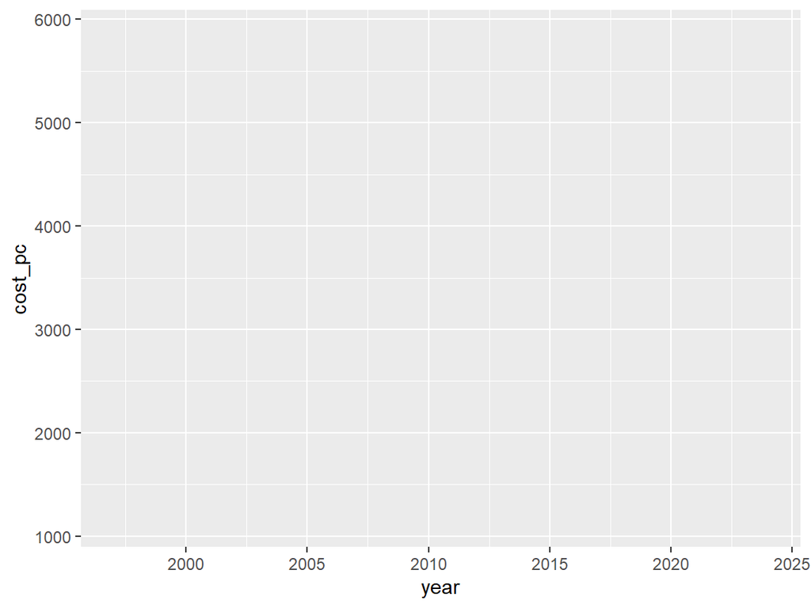

```r
costs_graph |>
    ggplot(
      aes(x = year, y = cost_pc)
    )
```

## Geometries (~the type of plot)

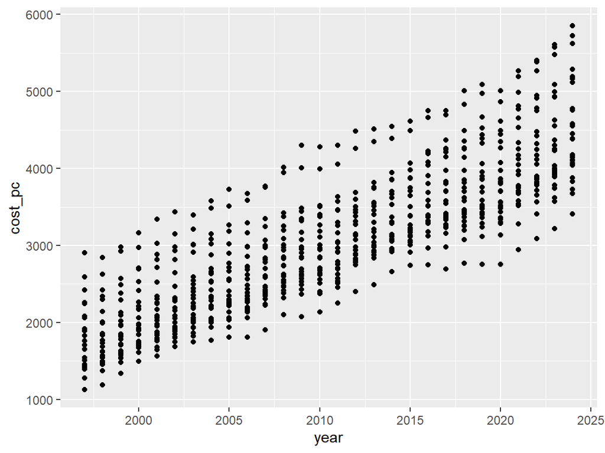

```r
costs_graph |>
    ggplot(
      aes(x = year, y = cost_pc)
    ) +
    geom_point()
```

## Geometries (~the type of plot)

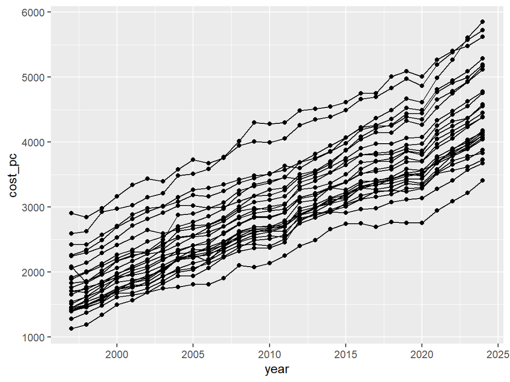

```r
costs_graph |>
    ggplot(
      aes(x = year, y = cost_pc, group = canton)
    ) +
    geom_point() +
    geom_line()
```

## Geometries (~the type of plot)

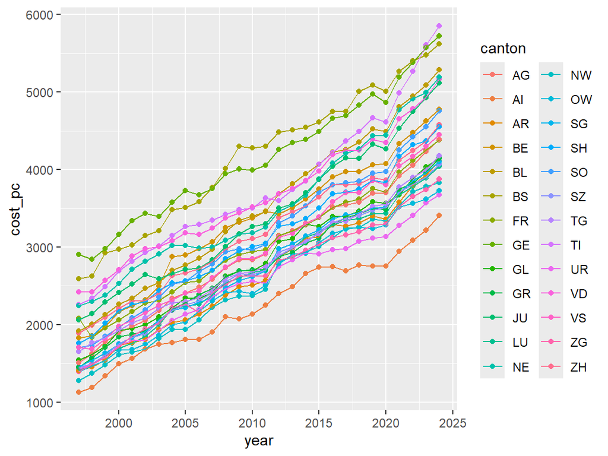

```r
costs_graph |>
    ggplot(
      aes(x = year, y = cost_pc, group = canton, color = canton)
    ) +
    geom_point() +
    geom_line()
```

## Facets

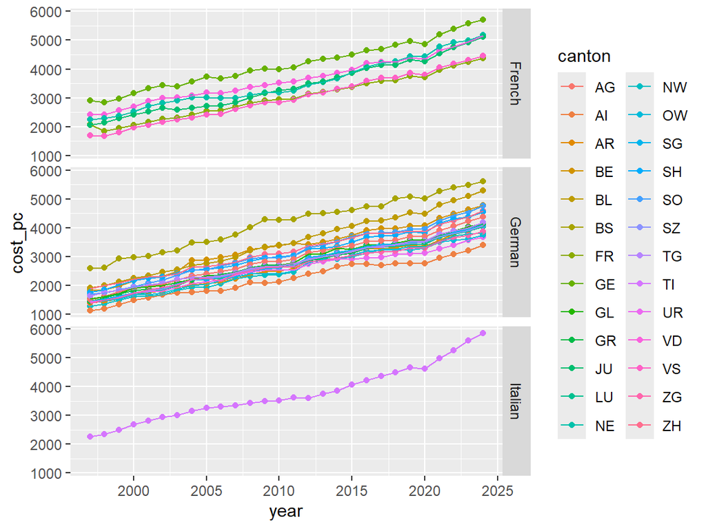

```r
costs_graph |>
    ggplot(
      aes(x = year, y = cost_pc, group = canton, color = canton)
    ) +
    geom_point() +
    geom_line() +
    facet_grid(region ~ .)
```

## Additional layers and statistics

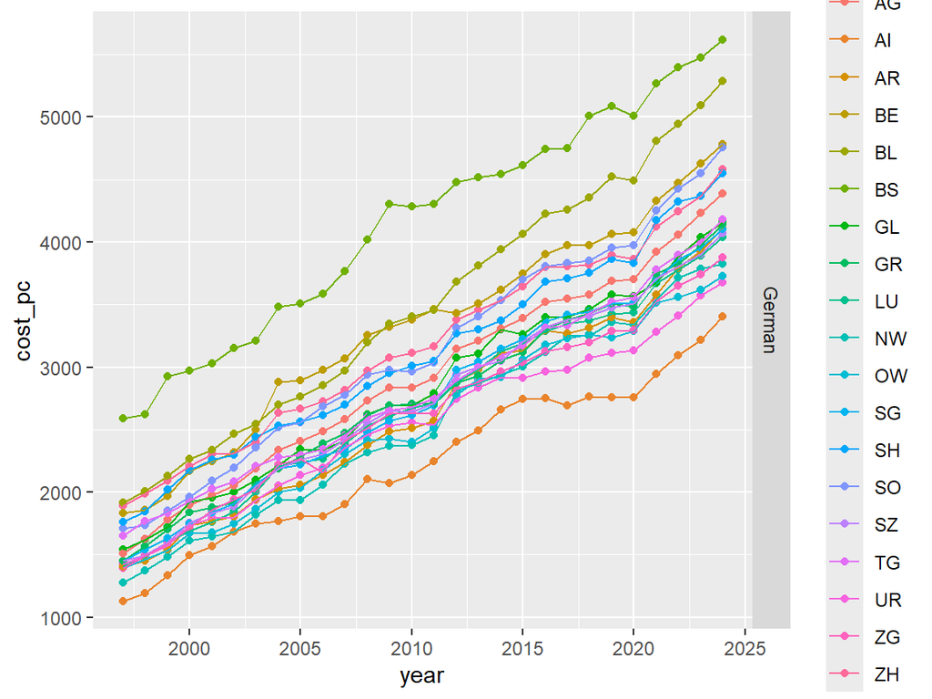

```r
costs_graph |>
    filter(region == "German") |>
    ggplot(
      aes(x = year, y = cost_pc, group = canton, color = canton)
    ) +
    geom_point() +
    geom_line() +
    facet_grid(region ~ .)
```

## Additional layers and statistics

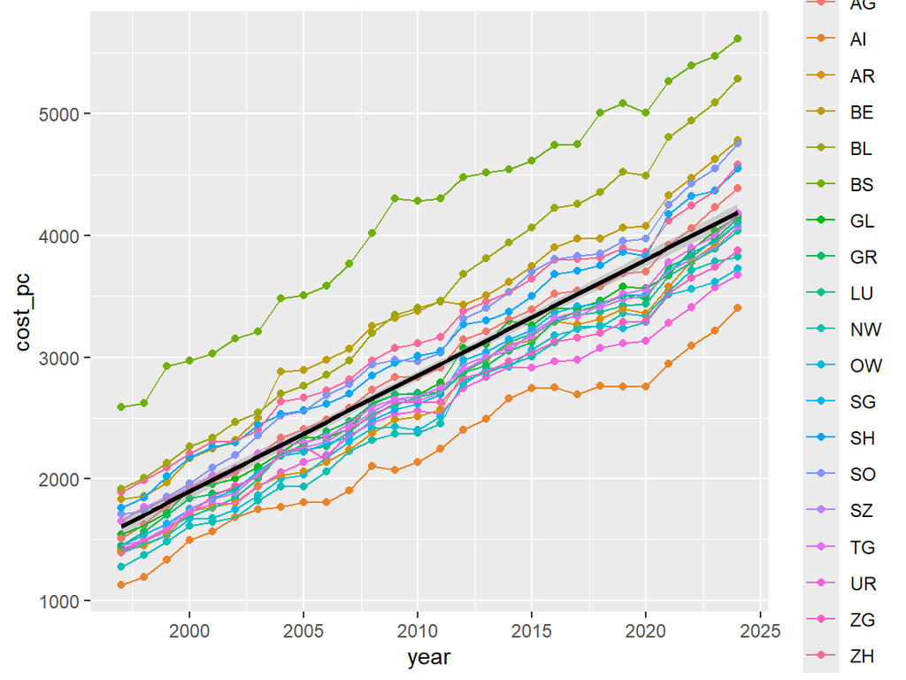

```r
costs_graph |>
    filter(region == "German") |>
    ggplot(
      aes(x = year, y = cost_pc)
    ) +
    geom_point(aes(color = canton)) +
    geom_line(aes(color = canton)) +
    geom_smooth(method = "lm", color = "black")
```

## Adjust the coordinate system or zoom.

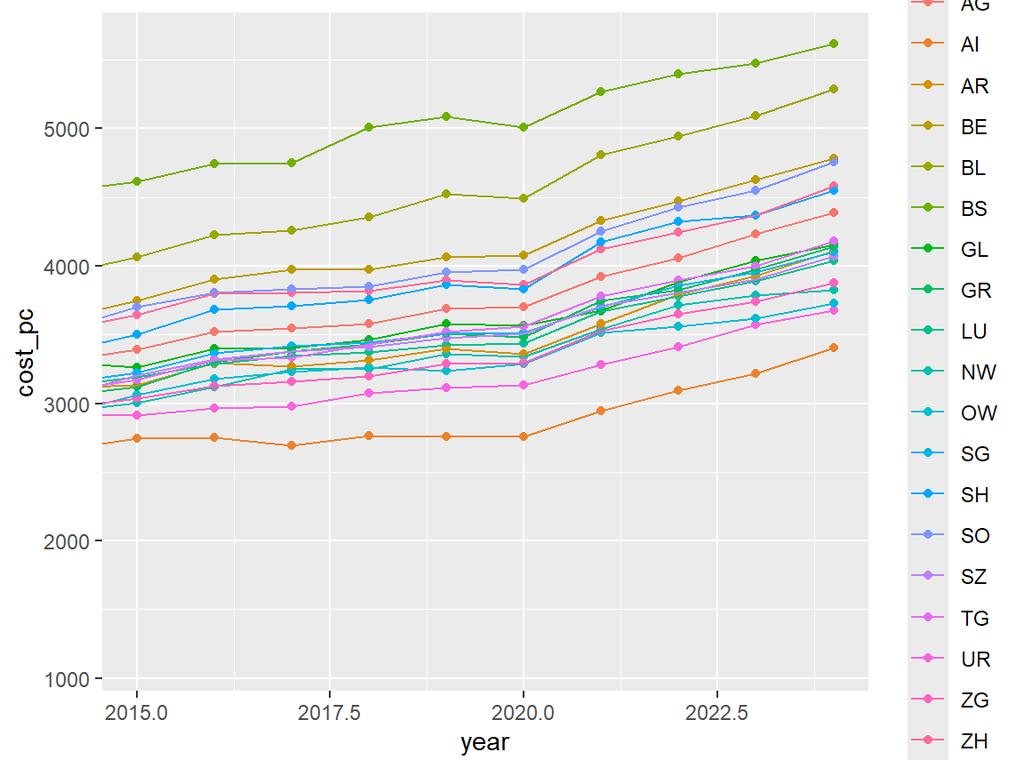

```r
costs_graph |>
    filter(region == "German") |>
    ggplot(
      aes(x = year, y = cost_pc, group = canton, color = canton)
    ) +
    geom_point() +
    geom_line() +
    coord_cartesian(xlim = c(2015, NA))
```

## Save graph before final styling

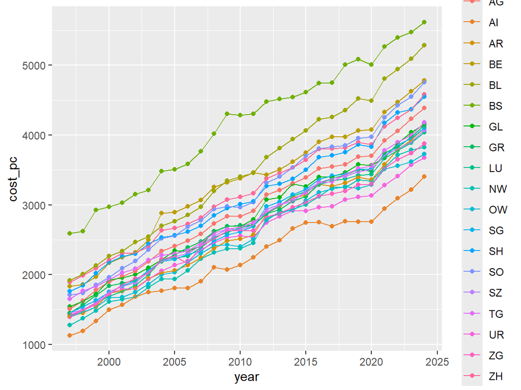

```r
p <- costs_graph |>
    filter(region == "German") |>
    ggplot(
      aes(x = year, y = cost_pc, group = canton, color = canton)
    ) +
    geom_point() +
    geom_line()

p
```

## Final styling (fonts, colors, title)

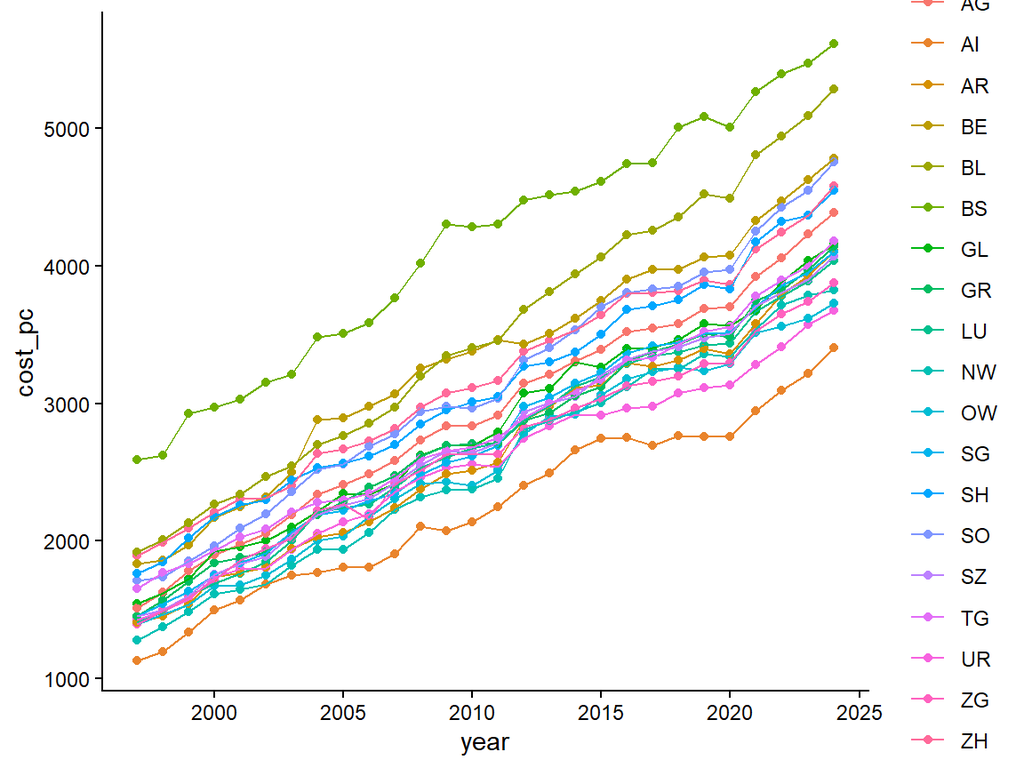

```r
p +
    theme_classic()
```

## Final styling (fonts, colors, title)

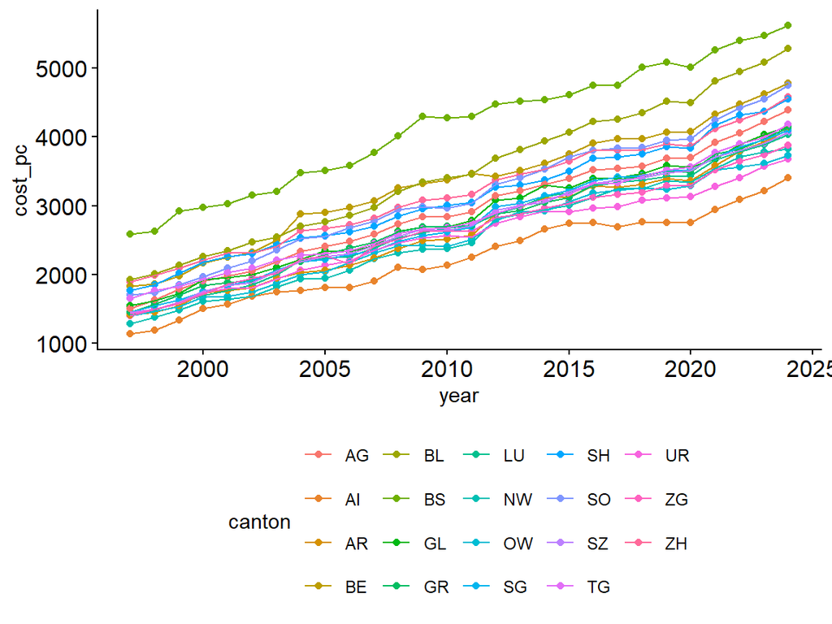

```r
p +
    theme_classic() +
    theme(
      legend.position = "bottom",
      axis.text = element_text(size = 12)
    )
```

## Final styling (fonts, colors, title)

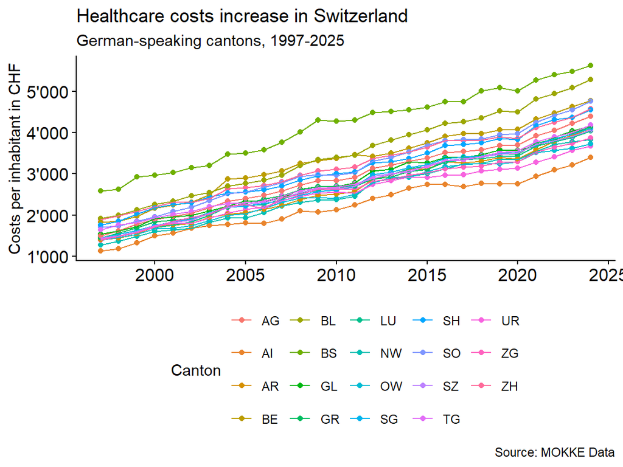

```r
p +
    scale_x_continuous(
      breaks = seq(2000, 2025, by = 5)
    ) +
    scale_y_continuous(
      labels = scales::label_comma(big.mark = "'")
    ) +
    labs(
      x = NULL,
      y = "Costs per inhabitant in CHF",
      title = "Healthcare costs increase in Switzerland",
      subtitle = "German-speaking cantons, 1997-2025",
      color = "Canton",
      caption = "Source: MOKKE Data"
    ) +
    theme_classic() +
    theme(
      legend.position = "bottom",
      axis.text = element_text(size = 12)
      )
```

## Use external themes from `ggthemes`

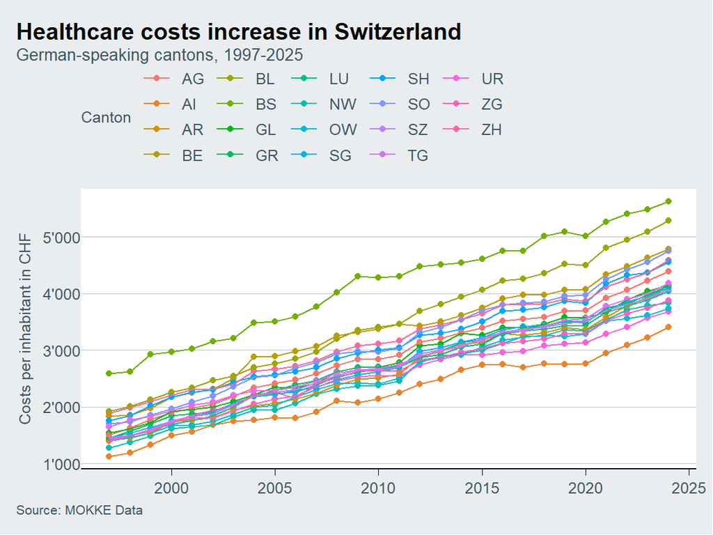

```r
library(ggthemes)

p +
    scale_x_continuous(
      breaks = seq(2000, 2025, by = 5)
    ) +
    scale_y_continuous(
      labels = scales::label_comma(big.mark = "'")
    ) +
    labs(
      x = NULL,
      y = "Costs per inhabitant in CHF",
      title = "Healthcare costs increase in Switzerland",
      subtitle = "German-speaking cantons, 1997-2025",
      color = "Canton",
      caption = "Source: MOKKE Data"
    ) +
    theme_classic() +
    theme(
      legend.position = "bottom",
      axis.text = element_text(size = 12)
      ) +
    theme_economist()
```

# Two tasks

## Task 1: Now back to our example…

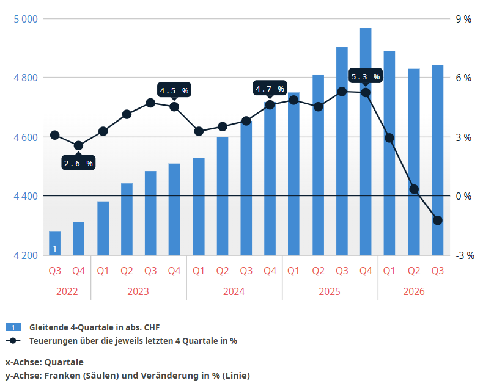

1. Reproduce this graph using `ggplot2` and the grammar of graphics.
2. Is this a good graph ⁉️

#### Task 1: A good start:

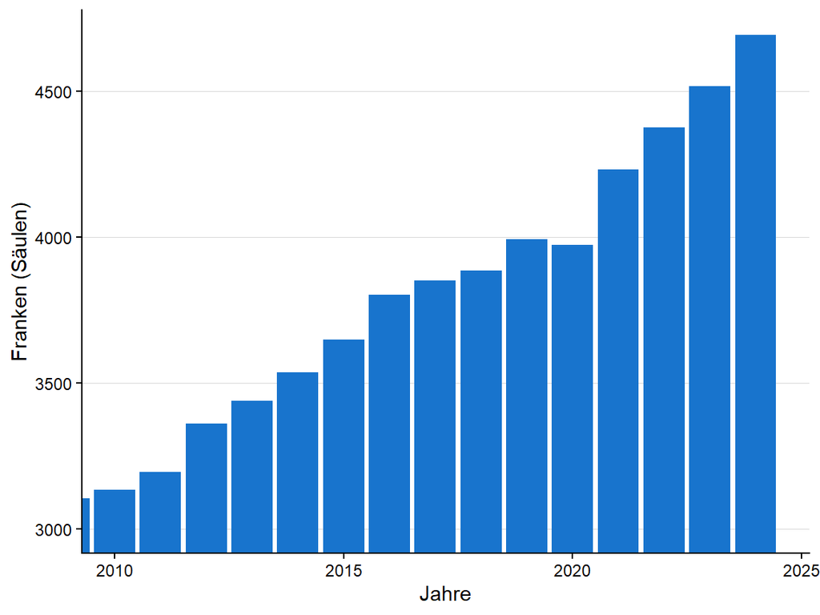

```r
costs |>
    filter(canton == "CH", sex == "total") |>
    mutate(year = year) |>
    ggplot(aes(x = year, y = cost_pc)) +
    geom_col(fill = "dodgerblue3") +
    coord_cartesian(ylim = c(3000, NA), xlim = c(2010, NA)) +
    labs(x = "Jahre", y = "Franken (Säulen)") +
    theme_classic() +
    theme(
      panel.grid.major.y = element_line(
        color = "grey85",
        linewidth = 0.3
      )
    )
```

## Task 2: *Tell me a story*

##### How fast did costs grow in Switzerland and per canton?

- Comparing CHF levels is not visually compelling (e.g., Geneva has always been more expensive than Appenzell).
- We want to know how growth compares between cantons.

#### Your task for next time

1. Keep only the totals (`sex == "total"`).
2. For each canton, compute an **index with 1997 = 100**
3. Plot one line per canton and for Switzerland as a country.

#### What do you notice? What is your story?

# Additional information

## Cheat sheet for `ggplot`

[figure not shown]

Link: https://rstudio.github.io/cheatsheets/html/data-visualization.html

## What graph should I draw? A cheat sheet

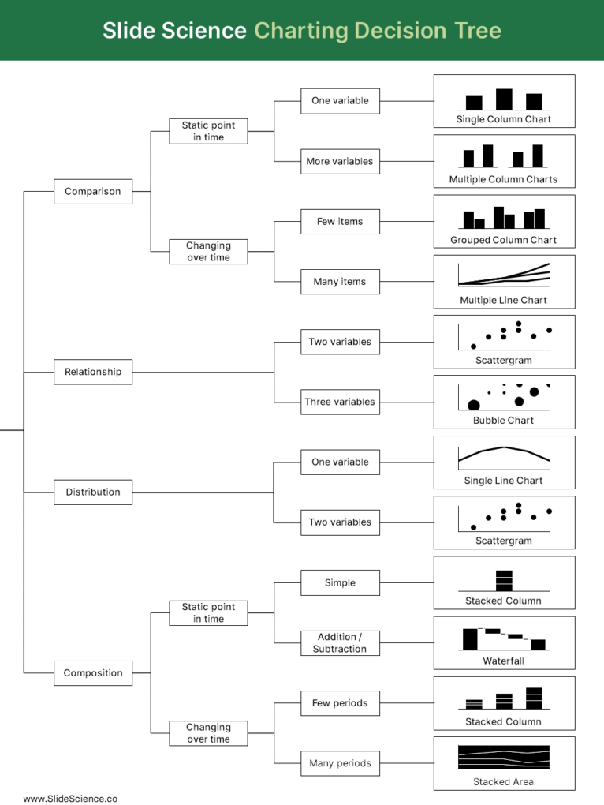

# Appendix: missing values

## Missing values in practice (1/4): is it really missing?

Health insurance costs in 2024. Customers without any bill have `NA`.  
(This often happens after a join: customers without claims have no row in the claims table…)

**Value is known but recorded badly. Here, no bill = 0 CHF.**

##### Decision: recode, don’t impute.

```r
costs
##   customer_id health_costs
## 1          23         9003
## 2         298           NA
## 3        1098        29304
## 4         101          175
## 5          44           NA
## 6        8098           NA
```

```r
costs |>
    summarise(costs = mean(health_costs, na.rm = TRUE))
##      costs
## 1 12827.33

costs |>
    mutate(cost = if_else(is.na(health_costs), 0, health_costs)) |>
    # coalesce(health_costs, 0)) |> # equivalent
    summarise(mean_cost = mean(cost))
##   mean_cost
## 1  6413.667
```

## Missing values in practice (2/4): MCAR

*The software crashed randomly for two answers when collecting information on depression score.*

- **Missing purely by chance?** **Yes, MCAR**

Drop observations. Make sure it does not affect precision.

```r
mcar
##         name gender score
## 1      Peter   male     4
## 2   Quagmire   male     2
## 3  Cleveland   male    NA
## 4        Joe   male     9
## 5      Chris   male     7
## 6      Brian   male    11
## 7       Lois female    10
## 8        Meg female    18
## 9     Bonnie female    NA
## 10     Donna female    10
## 11    Connie female    10
```

```r
mean(mcar$score, na.rm = T)
## [1] 9
```

## Missing values in practice (3/4): MAR

*Men skip the depression questionnaire more often than women. Within each gender, answering does not depend on the score itself (assumption).*

- **Missing purely by chance?** **No**
- **Other variables explain what is missing?** **Yes, MAR**

Impute within `gender`. Wisely, or neglegt…

```r
mar
##         name gender score
## 1      Peter   male    NA
## 2   Quagmire   male     2
## 3  Cleveland   male    NA
## 4        Joe   male    NA
## 5      Chris   male    NA
## 6      Brian   male    11
## 7       Lois female    10
## 8        Meg female    18
## 9     Bonnie female    NA
## 10     Donna female    10
## 11    Connie female    10
```

```r
mar |>
  mutate(score_sex = if_else(
    is.na(score), mean(score, na.rm = TRUE), score),
    .by = gender
  ) |>
  summarise(
    complete_cases = mean(score, na.rm = TRUE),
    sex_imputed    = mean(score_sex)
  )
##   complete_cases sex_imputed
## 1       10.16667           9
```

## Missing values in practice (4/4): MNAR

*People with very high incomes prefer to keep them private. Missingness depends on the variable income itself.*

- **Missing purely by chance?** **No**
- **Other variables explain what is missing?** **No, MNAR**

No code fixes it: report Income is missing *because* it is high.

```r
mnar
##         name age_group income_k
## 1      Peter     adult       55
## 2       Lois     adult       70
## 3        Meg      teen       10
## 4      Chris      teen        5
## 5     Connie      teen       12
## 6   Quagmire    senior       NA
## 7  Cleveland     adult       60
## 8        Joe     adult       85
## 9     Bonnie     adult       45
## 10     Donna     adult       65
## 11    Carter    senior       NA
```

```r
mnar |>
    summarise(
        mean_reported = mean(income_k, na.rm = TRUE),
        n_missing = sum(is.na(income_k)),
        n = n()
    )
```

```
  mean_reported n_missing  n
1      45.22222         2 11
```